# Calculating UTM locations for NEON Woody Vegetation structure data

Victoria Scholl

7/14/2018

## Introduction

Install required packages.

```r
# install geoNEON for the woody veg location calculation
library(devtools)
#install_github('NEONScience/NEON-geolocation/geoNEON', dependencies=TRUE)
library(geoNEON)

# install neon utilities for the stackByTable function
#install_github("NEONScience/NEON-utilities/neonDataStackR", dependencies=TRUE)
library (neonDataStackR)

# load other required libraries
library(dplyr)
library(raster)
library(sp)
library(rgdal)
```

Use **setwd()** to set your working directory and define relative path names to the woody vegetation data and canopy height model.

When downloaded from the Data Portal, the NEON woody vegetation structure data product is a zip file containing multiple zip files and a series of data tables. We can use the **stackByTable** function within NEON’s **neonDataStackR** package to unzip this series of directories and combine each of their contents into a single set of three data tables: (1) vst_apparentindividual (containing structural measurements for qualifying individuals), (2) vst_mappingandtagging (location and species of individual plants), and (3) vst_perplotperyear (a summary of the data collected). The *uid* (unique ID) value can be used to link observations across these data tables.

```r
# set working directory to use relative paths
setwd("~/github/Laphs/")

# define the path to the CHM to get the geographic extent and CRS
chm_filename = './data/NEON_D01_HARV_DP3_732000_4713000_CHM.tif'

# define the path to the zipped woody veg data
woody_veg_filename = './data/NEON_struct-woody-plant.zip'

# combine all data into a single set of 3 data tables
neonDataStackR::stackByTable(dpID = 'DP1.10098.001',
             filepath = woody_veg_filename,
             savepath = './data/stackedFiles/')
```

Let’s read the vst_mappingandtagging.csv file and see how many trees there are.

```r
# read the mappingandtagging data
woody_mapping_and_tagging = read.csv('./data/NEON_struct-woody-plant/stackedFiles/vst_mappingandtagging.csv')

# sanity check - there should be one unique ID per row
print(paste0('There are ', as.character(length(unique(woody_mapping_and_tagging$uid))),
             ' trees in the mapping_and_tagging file'))
```

```
## [1] "There are 7482 trees in the mapping_and_tagging file"
```

Woody stems are mapped using a distance and azimuth angle from a GPS-measured reference point. We need the *stemDistance* and *stemAzimuth* values to calculate UTM coordinates for each stem, but not all of the entries have these values. Let’s filter the data by keeping only the trees with stem distance and azimuth measurements.

```r
# keep only the entries with stemDistance and stemAzimuth information
woody_mapping_and_tagging <- woody_mapping_and_tagging[complete.cases(woody_mapping_and_tagging$stemAzimuth) &
                                                       complete.cases(woody_mapping_and_tagging$stemDistance),]

# check how many trees there are with location information (stem distance and azimuth)
print(paste0('There are ', as.character(length(unique(woody_mapping_and_tagging$uid))),
             ' trees with location information'))
```

```
## [1] "There are 2803 trees with location information"
```

Use the geoNEON R package to pull geolocation data for each reference point from the NEON API.

```r
# concatenate fields for namedLocation and pointID into new column called "namedLocationPointID"
woody_mapping_and_tagging$namedLocationPointID <- paste(woody_mapping_and_tagging$namedLocation,
                                                        woody_mapping_and_tagging$pointID, sep=".")

# get coordinates of the reference points for each tree measurement from the API
woody_utm <- geoNEON::def.extr.geo.os(woody_mapping_and_tagging, 'namedLocationPointID')

# get easting/northing of reference point ID
ref_east <- as.numeric(woody_utm$api.easting)
ref_north <- as.numeric(woody_utm$api.northing)
theta <- (woody_utm$stemAzimuth * pi) / 180
```

```r
# calculate easting and northing for each plant;
# add new columns to the woody_utm veg data frame
woody_utm$easting <- ref_east +
  woody_utm$stemDistance * sin(theta)
woody_utm$northing <- ref_north +
  woody_utm$stemDistance * cos(theta)

# get rid of any entries with NA values in the easting/northing columns
woody_utm_complete <- woody_utm[complete.cases(woody_utm$easting) &
                                complete.cases(woody_utm$stemDistance),]

# write the woody veg data with UTM (easting, northing) coordinates eo .csv
write.csv(woody_utm_complete,
          './output/woody_veg_locations.csv')
```

Write the tree locations to a shapefile too, for visualization in GIS software.

```r
# get the geographic extent of the tile we will use
chm_raster <- raster::raster(chm_filename)
chm_extent <- chm_raster@extent
chm_crs <- chm_raster@crs

# write a shapefile with the woody veg locations and other columns of interest
stem_locations <- woody_utm_complete %>%
  dplyr::select(individualID, scientificName, taxonID, easting, northing)

# assign spatial coordinates to each entry, and coordinate reference system
sp::coordinates(stem_locations) <- ~easting+northing
sp::proj4string(stem_locations) <- chm_crs

# write shapefile
suppressWarnings(
  rgdal::writeOGR(stem_locations,
           './output/',
           'woody_veg_location_species',
           driver="ESRI Shapefile",
           overwrite_layer = TRUE))
```

Let’s plot the tree locations on top of the CHM.

```r
# keep only the trees within in the current CHM tile extent
stem_locations_in <- raster::crop(stem_locations,
                                  chm_extent)
# count how many trees are left
print(paste0(as.character(nrow(stem_locations_in)),
             " trees are within the current CHM extent"))
```

```
## [1] "439 trees are within the current CHM extent"
```

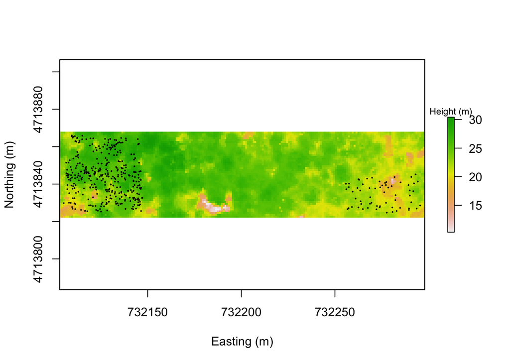

```r
# crop the CHM to the area containing stems.
# add a 5m buffer to the edges.
chm_cropped <- raster::crop(chm_raster,
                            extent(stem_locations_in) + 5)

# plot the CHM and add tree locations as points
plot(chm_cropped, legend=TRUE,
     xlab = 'Easting (m)', ylab = 'Northing (m)',
     legend.args=list(text='Height (m)', cex=0.75))
points(stem_locations_in, pch = 20, cex = 0.25)
```